# SOC4001 Procesamiento avanzado de bases de datos en R

Tarea 5

Ponderación: 12% de la nota final del curso

Formato: Desarrollar esta tarea en un RScript, agregando comentarios cuando sea necesario.

## Instrucciones:

Usa el siguiente cógigo para cargar la base de datos sobre Covid-19 usados en clase y seleccionar sólo las variables numéricas más el identificador de continente.

```r
library("tidyverse")
library("cowplot")
library("lubridate")
library("viridis")

path <- url("https://raw.githubusercontent.com/mebucca/dar_soc4001/master/slides/class_12/covid_data.csv")
# leer archivo csv
covid_data <- read_delim(path, delim=";")
covid_data <-  covid_data %>% select(continent, total_cases_per_million, total_deaths_per_million, new_cases_per_million, new_deaths_per_million)
```

Los datos deben verse así:

```
## Rows: 56,748
## Columns: 5
## $ continent                <chr> "Asia", "Asia", "Asia", "Asia", "Asia", "Asia…
## $ total_cases_per_million  <dbl> NA, NA, NA, NA, NA, NA, NA, NA, NA, NA, NA, N…
## $ total_deaths_per_million <dbl> NA, NA, NA, NA, NA, NA, NA, NA, NA, NA, NA, N…
## $ new_cases_per_million    <dbl> 0, 0, 0, 0, 0, 0, 0, 0, 0, 0, 0, 0, 0, 0, 0, …
## $ new_deaths_per_million   <dbl> 0, 0, 0, 0, 0, 0, 0, 0, 0, 0, 0, 0, 0, 0, 0, …
```

## Ejercicio

1. Usando las funciones `nest()` y `map()`del paquete `purrr`, para cada continente crea un matriz de correlaciones entre todas las variables.
- Nota: para crear la matriz de correlaciones la función `map()` debe tomar el siguente argumento: `.f = ~ cor(., use = "pairwise.complete.obs")`. Guarda la matriz en una nueva columna llamada `corrs` y asigna el resultado a un nuevo objecto llamado `miscors`.

El objeto `miscors` debe verse así:

| continent | data | corrs |
| --- | --- | --- |
| Asia |  |  |
| Europe |  |  |
| Africa |  |  |
| North America |  |  |
| South America |  |  |
| Oceania |  |  |

y cada matriz de correlación contenida en `corrs` de ve así

```
##                          total_cases_per_million total_deaths_per_million
## total_cases_per_million               1.00000000               0.02057843
## total_deaths_per_million              0.02057843               1.00000000
## new_cases_per_million                 0.16873694               0.06326542
## new_deaths_per_million                0.16440194              -0.13163684
##                          new_cases_per_million new_deaths_per_million
## total_cases_per_million             0.16873694             0.16440194
## total_deaths_per_million            0.06326542            -0.13163684
## new_cases_per_million               1.00000000            -0.02377809
## new_deaths_per_million             -0.02377809             1.00000000
```

2. Continua trabajando con el objeto `miscors`. Usando las funciones `nest()` y `map()`del paquete `purrr`, crea nueva columna llamada `mean_cor` que contenga el promedio de cada matriz de correlacciones almacenada en la columna `corrs`.
- Nota: para el promedio de las correlaciones la función `map()` debe tomar el siguente argumento: `.f = ~mean(., na.rm=T)`. Asigna el resultado a un nuevo objecto llamado `miscors`. El nuevo objeto `miscors` debe verse así:

| continent | data | corrs | mean_cor |
| --- | --- | --- | --- |
| Asia |  |  |  |
| Europe |  |  |  |
| Africa |  |  |  |
| North America |  |  |  |
| South America |  |  |  |
| Oceania |  |  |  |

3. Usando la función `unnest()` crea un nueva base de datos que contenga solo la correlación promedio `mean_cor` por continente. Asigna el resultado a un nuevo objecto llamado `miscors`. El nuevo objeto `miscors` debe verse así:

| continent | mean_cor |
| --- | --- |
| Asia | 0.2826960 |
| Europe | 0.3759965 |
| Africa | 0.2392888 |
| North America | 0.3795747 |
| South America | 0.3529630 |
| Oceania | 0.3270454 |

4. En base a los datos almacenados en `miscors` crea el siguiente gráfico usando la geometría `geom_bar(stat = "identity")`:

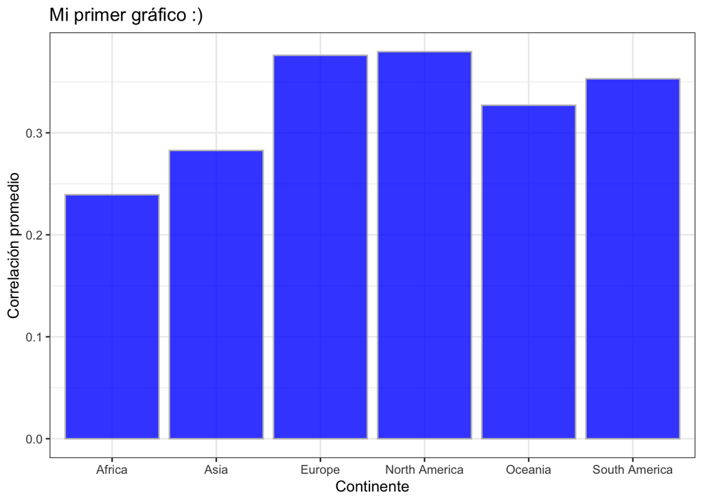